# Midewin_Diversity_Comp.Results.Figures

Marissa Zaricor

2026-05-11

## Set up and Overview

### Running Title: Management modifies consumer top-down control of plant diversity in grassland restoration

**Background:** Quantifying the independent and interactive effects of management (fire, mow, herbicide, none) and consumers (bison, small mammals, no mammals) on plant community composition and diversity (species richness, Shannon diversity, and evenness) during tallgrass prairie restoration

**Author:** Marissa Zaricor

**Co-authors:** Lauren Sullivan

**Created:** 2025-05-16

**Files:**

1. *Midewin_Cover_21_24.csv* - contains plant cover, codes, taxon, etc. (latest updated version Jan 2025)
2. *Midewin_Aug-Aug_Grazing_Influence_22_24.csv*- bison raster data for total (sum by year) and weighted total (sum of weighted by month/season) but aug year-1 to aug year current. (last updated Jan 2025)

**Last Updated:** 2026-05-11

#### Libraries and Files

#### Data cleaning

Code for ggplot themes for publications

Code for figures to plot dodged/jittered points

## Species Richness

#### Calculate species richness

#### Add in bison covariate data

#### Fit the model

#### Check assumptions

#### r2

#### Post-hoc comparisons

```
## management_trt = control:
##  contrast estimate   SE df t.ratio p.value
##  XX - SX    -0.500 0.95 57  -0.526  0.8587
##  XX - SB    -3.333 0.95 57  -3.510  0.0025
##  SX - SB    -2.833 0.95 57  -2.983  0.0115
##
## management_trt = fire:
##  contrast estimate   SE df t.ratio p.value
##  XX - SX     0.500 0.95 57   0.526  0.8587
##  XX - SB    -2.333 0.95 57  -2.457  0.0444
##  SX - SB    -2.833 0.95 57  -2.983  0.0115
##
## management_trt = herbicide:
##  contrast estimate   SE df t.ratio p.value
##  XX - SX    -1.667 0.95 57  -1.755  0.1941
##  XX - SB    -0.667 0.95 57  -0.702  0.7633
##  SX - SB     1.000 0.95 57   1.053  0.5470
##
## management_trt = mow:
##  contrast estimate   SE df t.ratio p.value
##  XX - SX    -1.167 0.95 57  -1.228  0.4415
##  XX - SB    -1.000 0.95 57  -1.053  0.5470
##  SX - SB     0.167 0.95 57   0.175  0.9832
##
## P value adjustment: tukey method for comparing a family of 3 estimates
```

```
## herbivory_trt = XX:
##  contrast             estimate   SE df t.ratio p.value
##  control - fire      -4.000002 1.09 57  -3.677  0.0029
##  control - herbicide -2.500000 1.09 57  -2.298  0.1105
##  control - mow       -4.000003 1.09 57  -3.677  0.0029
##  fire - herbicide     1.500002 1.09 57   1.379  0.5177
##  fire - mow          -0.000001 1.09 57   0.000  1.0000
##  herbicide - mow     -1.500003 1.09 57  -1.379  0.5177
##
## herbivory_trt = SX:
##  contrast             estimate   SE df t.ratio p.value
##  control - fire      -3.000005 1.09 57  -2.757  0.0380
##  control - herbicide -3.666658 1.09 57  -3.370  0.0072
##  control - mow       -4.666669 1.09 57  -4.289  0.0004
##  fire - herbicide    -0.666653 1.09 57  -0.613  0.9276
##  fire - mow          -1.666664 1.09 57  -1.532  0.4255
##  herbicide - mow     -1.000011 1.09 57  -0.919  0.7947
##
## herbivory_trt = SB:
##  contrast             estimate   SE df t.ratio p.value
##  control - fire      -2.999999 1.09 57  -2.757  0.0380
##  control - herbicide  0.166671 1.09 57   0.153  0.9987
##  control - mow       -1.666671 1.09 57  -1.532  0.4255
##  fire - herbicide     3.166670 1.09 57   2.911  0.0257
##  fire - mow           1.333328 1.09 57   1.226  0.6134
##  herbicide - mow     -1.833342 1.09 57  -1.685  0.3409
##
## P value adjustment: tukey method for comparing a family of 4 estimates
```

#### Data visualization of Species Richness 2024 West Pasture

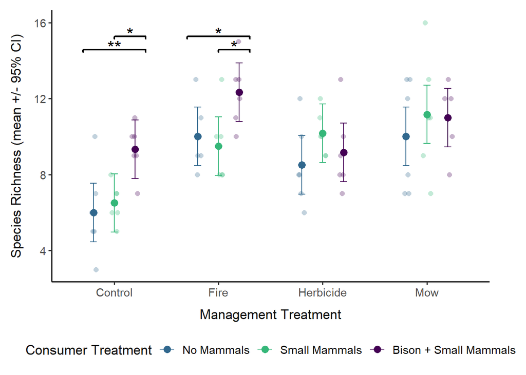

Table: GLMM Spec Rich 2024

Table: Anova Spec Rich 2024

Table: Post Hoc Comparisons Spec Rich 2024

## Richness Delta Model (23-24)

#### Calculate the difference from 2023 to 2024 in specrich

histogram

#### Fit the model

#### Check assumptions

#### Post-Hoc Comparisons

```
## management_trt = control:
##  contrast estimate   SE df t.ratio p.value
##  XX - SX     -1.40 1.13 49  -1.242  0.4348
##  XX - SB     -3.00 1.13 49  -2.661  0.0279
##  SX - SB     -1.60 1.13 49  -1.419  0.3391
##
## management_trt = fire:
##  contrast estimate   SE df t.ratio p.value
##  XX - SX     -1.82 1.09 49  -1.663  0.2295
##  XX - SB     -3.67 1.03 49  -3.562  0.0024
##  SX - SB     -1.85 1.09 49  -1.688  0.2200
##
## management_trt = herbicide:
##  contrast estimate   SE df t.ratio p.value
##  XX - SX     -1.13 1.10 49  -1.033  0.5601
##  XX - SB     -2.47 1.10 49  -2.249  0.0730
##  SX - SB     -1.33 1.03 49  -1.295  0.4046
##
## management_trt = mow:
##  contrast estimate   SE df t.ratio p.value
##  XX - SX      0.20 1.13 49   0.177  0.9828
##  XX - SB     -0.40 1.13 49  -0.355  0.9331
##  SX - SB     -0.60 1.13 49  -0.532  0.8560
##
## P value adjustment: tukey method for comparing a family of 3 estimates
```

```
##  contrast estimate    SE df t.ratio p.value
##  XX - SX     -1.04 0.556 49  -1.868  0.1590
##  XX - SB     -2.38 0.548 49  -4.349  0.0002
##  SX - SB     -1.35 0.548 49  -2.456  0.0457
##
## Results are averaged over the levels of: management_trt
## P value adjustment: tukey method for comparing a family of 3 estimates
```

Table: GLMM Delta Richness Model

Table: ANova Delta Richness Model

Table: Post Hoc Comparisons Delta Richness

#### Data Visualization Delta Richness Herbivory Treatment Main Effects

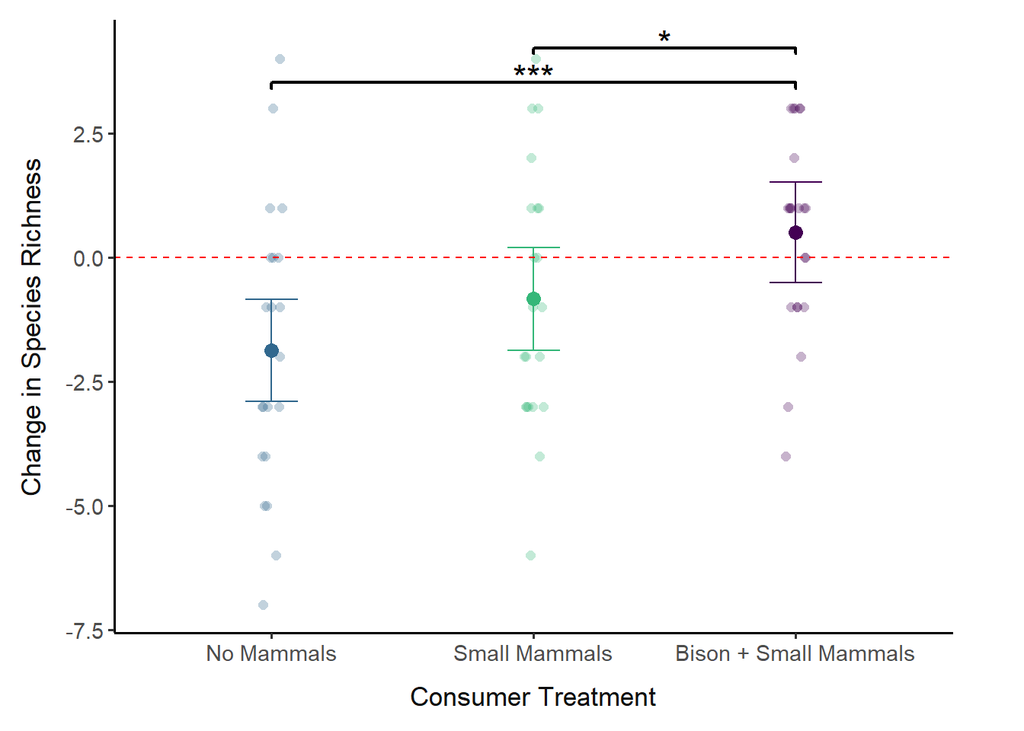

### Supporting Information Figure Delta Richness Management X Herbivory Treatments

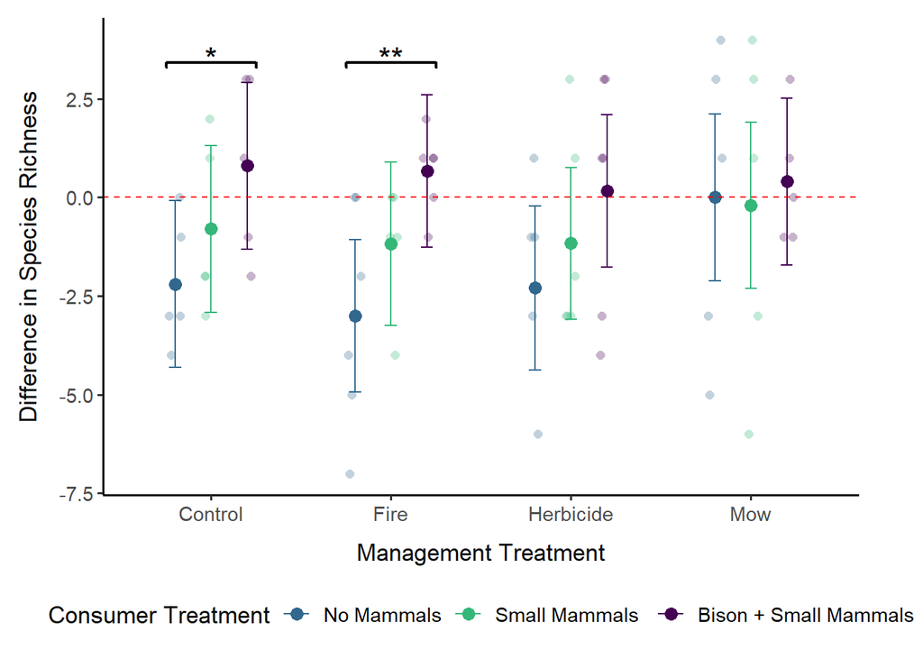

2021 Plant Spec Rich SB only plots though no herbivory treatments

Table: ANova 2021 Richness Model

## Shannon and Evenness Metrics

#### Data Cleaning and Set up

Calculate shannon and evennes metrics

Shannon Diversity 2024

#### Fit model for Shannon diversrity

Table : Summary of GLMM for shannon diversity in response to management, herbivory and their interaction using data from 2024.

Table : Type III Wald Chisquare tests

Evar model

Although the bounded of the evenness indices and some residual patters would suggest we use beta GLMMs instead which had margnially better assumptions checks since the Guassian models showed no strong overdispersion or zero inflation, will use that for ease and to keep model analysis similar as possible. Either way, there was no significant effects

Table 5: Summary of anova for EVAR in response to management, herbivory and their interaction using data from 2024.

Pielou evenness

Same as above. Also beta model reinforces that the single coefficient is non-significant here. Will still use guassian model for results

Table 5: Summary of anova for pielou’s evennes in response to management, herbivory and their interaction using data from 2024.

## Comm Comp 2024

### Data Cleaning and Set up for Matrix

Permanova

Table: PERMANOVA 2024

Table permdisp test

Post Hoc Comparisons

Table . Pairwise comparisons of plant community composition for interactive effects in west pasture 2024.

Table Comparisons Comm Comp for Herbivory Main Effects 2024

Table Comparisons Management main effects Permanova 2024

#### Data Visualization 2024 West Pasture

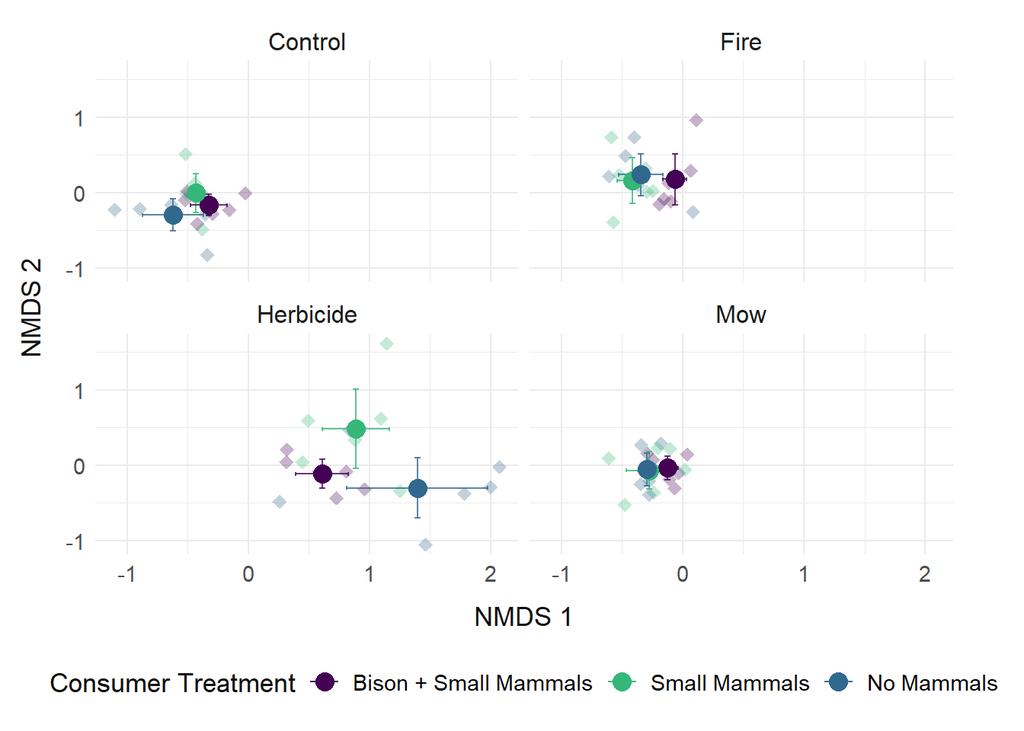

#### Subset Data to run betadispersion tests within each management treatment

Control Subset

Mow Subset

#### Data Visualization Herbicide Distance to Centroid Plot

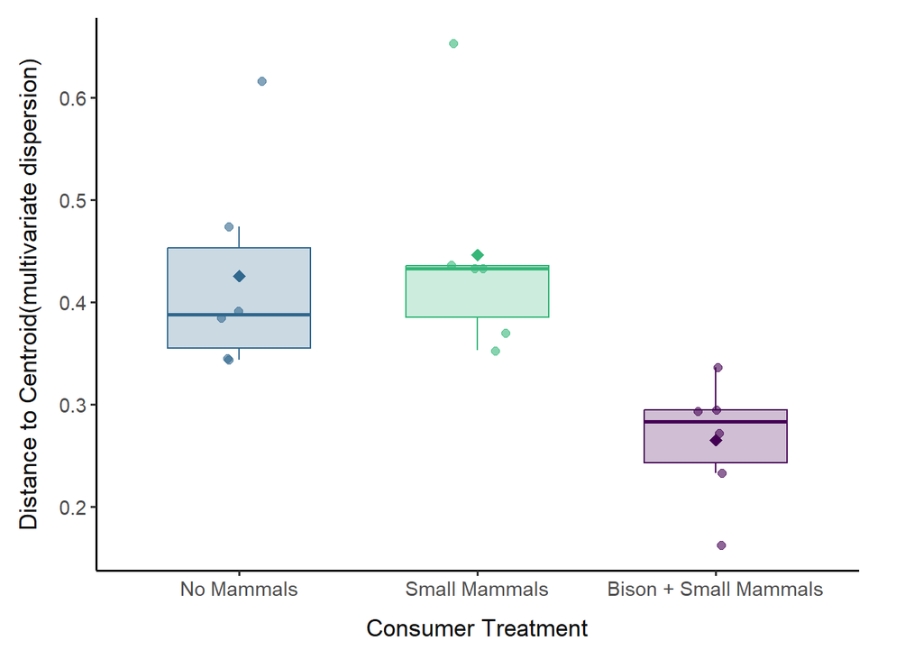

Table: PERMANOVA Subset Herbicide

Table Comparisons Comm Comp for Herbicide Subset

Table: Beta Dispersion for Herbicide Treatment

## 2023 & 2024 NMDS

#### data wrangling

Table: PERMANOVA

#### Visualization 2023-2024 West pasture

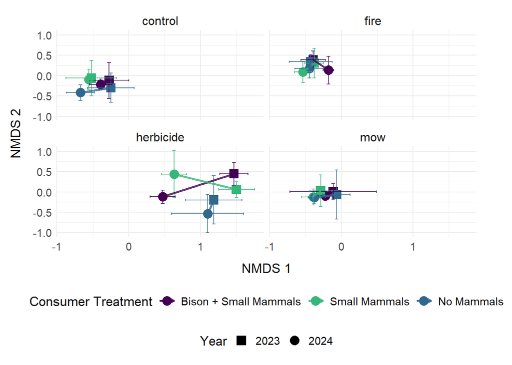

## 2021 NMDS West

### Data Wrangling

Table S #. PERMANOVA results from plant community composition in the bison pasture in 2021.